```python
import pandas as pd
import numpy as np
import seaborn as sb
from IPython.display import display
import matplotlib.pyplot as plt
```

1. Read the dataset

```python
train = pd.read_csv("Churn.csv")
overview = train.head(10)
target = train['Exited']
display(overview)
```

|  | RowNumber | CustomerId | Surname | CreditScore | Geography | Gender | Age | Tenure | Balance | NumOfProducts | HasCrCard | IsActiveMember | EstimatedSalary | Exited |
| --- | --- | --- | --- | --- | --- | --- | --- | --- | --- | --- | --- | --- | --- | --- |
| 0 | 1 | 15634602 | Hargrave | 619 | France | Female | 42 | 2 | 0.00 | 1 | 1 | 1 | 101348.88 | 1 |
| 1 | 2 | 15647311 | Hill | 608 | Spain | Female | 41 | 1 | 83807.86 | 1 | 0 | 1 | 112542.58 | 0 |
| 2 | 3 | 15619304 | Onio | 502 | France | Female | 42 | 8 | 159660.80 | 3 | 1 | 0 | 113931.57 | 1 |
| 3 | 4 | 15701354 | Boni | 699 | France | Female | 39 | 1 | 0.00 | 2 | 0 | 0 | 93826.63 | 0 |
| 4 | 5 | 15737888 | Mitchell | 850 | Spain | Female | 43 | 2 | 125510.82 | 1 | 1 | 1 | 79084.10 | 0 |
| 5 | 6 | 15574012 | Chu | 645 | Spain | Male | 44 | 8 | 113755.78 | 2 | 1 | 0 | 149756.71 | 1 |
| 6 | 7 | 15592531 | Bartlett | 822 | France | Male | 50 | 7 | 0.00 | 2 | 1 | 1 | 10062.80 | 0 |
| 7 | 8 | 15656148 | Obinna | 376 | Germany | Female | 29 | 4 | 115046.74 | 4 | 1 | 0 | 119346.88 | 1 |
| 8 | 9 | 15792365 | He | 501 | France | Male | 44 | 4 | 142051.07 | 2 | 0 | 1 | 74940.50 | 0 |
| 9 | 10 | 15592389 | H? | 684 | France | Male | 27 | 2 | 134603.88 | 1 | 1 | 1 | 71725.73 | 0 |

```
No handles with labels found to put in legend.
```

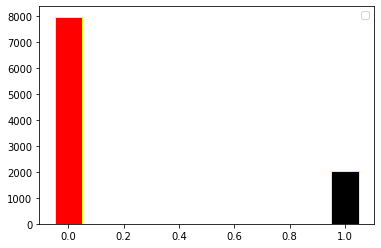

```python
%matplotlib inline
labels = [0,1]
plt.bar(labels[0],target_0, width=0.1,color = 'red',edgecolor='yellow')
plt.bar(labels[1],target_1,width=0.1,color = 'black',edgecolor='yellow')
plt.legend()
```

```python
train.info()
```

```
<class 'pandas.core.frame.DataFrame'>
RangeIndex: 10000 entries, 0 to 9999
Data columns (total 14 columns):
RowNumber          10000 non-null int64
CustomerId         10000 non-null int64
Surname            10000 non-null object
CreditScore        10000 non-null int64
Geography          10000 non-null object
Gender             10000 non-null object
Age                10000 non-null int64
Tenure             10000 non-null int64
Balance            10000 non-null float64
NumOfProducts      10000 non-null int64
HasCrCard          10000 non-null int64
IsActiveMember     10000 non-null int64
EstimatedSalary    10000 non-null float64
Exited             10000 non-null int64
dtypes: float64(2), int64(9), object(3)
memory usage: 1.1+ MB
```

```python
train.describe()
```

|  | RowNumber | CustomerId | CreditScore | Age | Tenure | Balance | NumOfProducts | HasCrCard | IsActiveMember | EstimatedSalary | Exited |
| --- | --- | --- | --- | --- | --- | --- | --- | --- | --- | --- | --- |
| count | 10000.00000 | 1.000000e+04 | 10000.000000 | 10000.000000 | 10000.000000 | 10000.000000 | 10000.000000 | 10000.00000 | 10000.000000 | 10000.000000 | 10000.000000 |
| mean | 5000.50000 | 1.569094e+07 | 650.528800 | 38.921800 | 5.012800 | 76485.889288 | 1.530200 | 0.70550 | 0.515100 | 100090.239881 | 0.203700 |
| std | 2886.89568 | 7.193619e+04 | 96.653299 | 10.487806 | 2.892174 | 62397.405202 | 0.581654 | 0.45584 | 0.499797 | 57510.492818 | 0.402769 |
| min | 1.00000 | 1.556570e+07 | 350.000000 | 18.000000 | 0.000000 | 0.000000 | 1.000000 | 0.00000 | 0.000000 | 11.580000 | 0.000000 |
| 25% | 2500.75000 | 1.562853e+07 | 584.000000 | 32.000000 | 3.000000 | 0.000000 | 1.000000 | 0.00000 | 0.000000 | 51002.110000 | 0.000000 |
| 50% | 5000.50000 | 1.569074e+07 | 652.000000 | 37.000000 | 5.000000 | 97198.540000 | 1.000000 | 1.00000 | 1.000000 | 100193.915000 | 0.000000 |
| 75% | 7500.25000 | 1.575323e+07 | 718.000000 | 44.000000 | 7.000000 | 127644.240000 | 2.000000 | 1.00000 | 1.000000 | 149388.247500 | 0.000000 |
| max | 10000.00000 | 1.581569e+07 | 850.000000 | 92.000000 | 10.000000 | 250898.090000 | 4.000000 | 1.00000 | 1.000000 | 199992.480000 | 1.000000 |

```python
cal= train[train['IsActiveMember']==1].count()
cal2 = train[train['Exited']==1].count()
ave = (cal2/(cal+cal2))*100
va= '%.1f '  % ave[1]
print(va+'%')
```

```
28.3 %
```

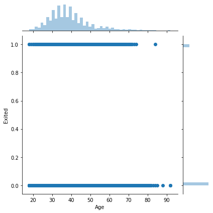

```python
axis = sb.jointplot(x='Age',y='Exited',data = data)
```

```python
array1 = np.array(train['IsActiveMember'])
array2 = np.array(train['Exited'])
index = len(array1)
count = 0
for i in range(index):
    if(array1[i]==1 and array2[i]==1):
        count +=1
print(count)
```

```
735
```

In previous section we are creating code to count all matched 1 with another 1 in exited column ,that is is activate user is effects on the output 735.

```python
France = float(train[train['Geography']=='France']['Geography'].count())
Spain = float(train[train['Geography']=='Spain']['Geography'].count())
Germany = float(train[train['Geography']=='Germany']['Geography'].count())
print(France+Spain+Germany)
```

```
10000.0
```

in this section we are making to features preprocessing to be acceptable to feed it to classifier. and in this section below in create label encoder to geography and gender to be numbers that each number refer to name that can not accepted to classifier, example gender have two types female and male this function LabelEncoder make this two types in encode like 1 refer to male and 0 refer to female. if we have more types the number is increased.

```python
from sklearn.preprocessing import LabelEncoder,OneHotEncoder
label = LabelEncoder()
X['Geography'] = label.fit_transform(X['Geography'])
X['Gender'] = label.fit_transform(X['Gender'])
print(X['Gender'].head(7))
```

```
0    0
1    0
2    0
3    0
4    0
5    1
6    1
Name: Gender, dtype: int32
```

```python
onehotencoding = OneHotEncoder(categorical_features = [1])
X = onehotencoding.fit_transform(X).toarray()
print(X)
```

```
[[1.0000000e+00 0.0000000e+00 0.0000000e+00 ... 1.0000000e+00
  1.0000000e+00 1.0134888e+05]
 [0.0000000e+00 0.0000000e+00 1.0000000e+00 ... 0.0000000e+00
  1.0000000e+00 1.1254258e+05]
 [1.0000000e+00 0.0000000e+00 0.0000000e+00 ... 1.0000000e+00
  0.0000000e+00 1.1393157e+05]
 ...
 [1.0000000e+00 0.0000000e+00 0.0000000e+00 ... 0.0000000e+00
  1.0000000e+00 4.2085580e+04]
 [0.0000000e+00 1.0000000e+00 0.0000000e+00 ... 1.0000000e+00
  0.0000000e+00 9.2888520e+04]
 [1.0000000e+00 0.0000000e+00 0.0000000e+00 ... 1.0000000e+00
  0.0000000e+00 3.8190780e+04]]
```

```python
import xgboost as xgb
from sklearn.metrics import mean_squared_error
import pandas as pd
import numpy as np
```

```python
#view the data
train
```

|  | RowNumber | CustomerId | Surname | CreditScore | Geography | Gender | Age | Tenure | Balance | NumOfProducts | HasCrCard | IsActiveMember | EstimatedSalary | Exited |
| --- | --- | --- | --- | --- | --- | --- | --- | --- | --- | --- | --- | --- | --- | --- |
| 0 | 1 | 15634602 | Hargrave | 619 | France | Female | 42 | 2 | 0.00 | 1 | 1 | 1 | 101348.88 | 1 |
| 1 | 2 | 15647311 | Hill | 608 | Spain | Female | 41 | 1 | 83807.86 | 1 | 0 | 1 | 112542.58 | 0 |
| 2 | 3 | 15619304 | Onio | 502 | France | Female | 42 | 8 | 159660.80 | 3 | 1 | 0 | 113931.57 | 1 |
| 3 | 4 | 15701354 | Boni | 699 | France | Female | 39 | 1 | 0.00 | 2 | 0 | 0 | 93826.63 | 0 |
| 4 | 5 | 15737888 | Mitchell | 850 | Spain | Female | 43 | 2 | 125510.82 | 1 | 1 | 1 | 79084.10 | 0 |
| 5 | 6 | 15574012 | Chu | 645 | Spain | Male | 44 | 8 | 113755.78 | 2 | 1 | 0 | 149756.71 | 1 |
| 6 | 7 | 15592531 | Bartlett | 822 | France | Male | 50 | 7 | 0.00 | 2 | 1 | 1 | 10062.80 | 0 |
| 7 | 8 | 15656148 | Obinna | 376 | Germany | Female | 29 | 4 | 115046.74 | 4 | 1 | 0 | 119346.88 | 1 |
| 8 | 9 | 15792365 | He | 501 | France | Male | 44 | 4 | 142051.07 | 2 | 0 | 1 | 74940.50 | 0 |
| 9 | 10 | 15592389 | H? | 684 | France | Male | 27 | 2 | 134603.88 | 1 | 1 | 1 | 71725.73 | 0 |
| 10 | 11 | 15767821 | Bearce | 528 | France | Male | 31 | 6 | 102016.72 | 2 | 0 | 0 | 80181.12 | 0 |
| 11 | 12 | 15737173 | Andrews | 497 | Spain | Male | 24 | 3 | 0.00 | 2 | 1 | 0 | 76390.01 | 0 |
| 12 | 13 | 15632264 | Kay | 476 | France | Female | 34 | 10 | 0.00 | 2 | 1 | 0 | 26260.98 | 0 |
| 13 | 14 | 15691483 | Chin | 549 | France | Female | 25 | 5 | 0.00 | 2 | 0 | 0 | 190857.79 | 0 |
| 14 | 15 | 15600882 | Scott | 635 | Spain | Female | 35 | 7 | 0.00 | 2 | 1 | 1 | 65951.65 | 0 |
| 15 | 16 | 15643966 | Goforth | 616 | Germany | Male | 45 | 3 | 143129.41 | 2 | 0 | 1 | 64327.26 | 0 |
| 16 | 17 | 15737452 | Romeo | 653 | Germany | Male | 58 | 1 | 132602.88 | 1 | 1 | 0 | 5097.67 | 1 |
| 17 | 18 | 15788218 | Henderson | 549 | Spain | Female | 24 | 9 | 0.00 | 2 | 1 | 1 | 14406.41 | 0 |
| 18 | 19 | 15661507 | Muldrow | 587 | Spain | Male | 45 | 6 | 0.00 | 1 | 0 | 0 | 158684.81 | 0 |
| 19 | 20 | 15568982 | Hao | 726 | France | Female | 24 | 6 | 0.00 | 2 | 1 | 1 | 54724.03 | 0 |
| 20 | 21 | 15577657 | McDonald | 732 | France | Male | 41 | 8 | 0.00 | 2 | 1 | 1 | 170886.17 | 0 |
| 21 | 22 | 15597945 | Dellucci | 636 | Spain | Female | 32 | 8 | 0.00 | 2 | 1 | 0 | 138555.46 | 0 |
| 22 | 23 | 15699309 | Gerasimov | 510 | Spain | Female | 38 | 4 | 0.00 | 1 | 1 | 0 | 118913.53 | 1 |
| 23 | 24 | 15725737 | Mosman | 669 | France | Male | 46 | 3 | 0.00 | 2 | 0 | 1 | 8487.75 | 0 |
| 24 | 25 | 15625047 | Yen | 846 | France | Female | 38 | 5 | 0.00 | 1 | 1 | 1 | 187616.16 | 0 |
| 25 | 26 | 15738191 | Maclean | 577 | France | Male | 25 | 3 | 0.00 | 2 | 0 | 1 | 124508.29 | 0 |
| 26 | 27 | 15736816 | Young | 756 | Germany | Male | 36 | 2 | 136815.64 | 1 | 1 | 1 | 170041.95 | 0 |
| 27 | 28 | 15700772 | Nebechi | 571 | France | Male | 44 | 9 | 0.00 | 2 | 0 | 0 | 38433.35 | 0 |
| 28 | 29 | 15728693 | McWilliams | 574 | Germany | Female | 43 | 3 | 141349.43 | 1 | 1 | 1 | 100187.43 | 0 |
| 29 | 30 | 15656300 | Lucciano | 411 | France | Male | 29 | 0 | 59697.17 | 2 | 1 | 1 | 53483.21 | 0 |
| ... | ... | ... | ... | ... | ... | ... | ... | ... | ... | ... | ... | ... | ... | ... |
| 9970 | 9971 | 15587133 | Thompson | 518 | France | Male | 42 | 7 | 151027.05 | 2 | 1 | 0 | 119377.36 | 0 |
| 9971 | 9972 | 15721377 | Chou | 833 | France | Female | 34 | 3 | 144751.81 | 1 | 0 | 0 | 166472.81 | 0 |
| 9972 | 9973 | 15747927 | Ch'in | 758 | France | Male | 26 | 4 | 155739.76 | 1 | 1 | 0 | 171552.02 | 0 |
| 9973 | 9974 | 15806455 | Miller | 611 | France | Male | 27 | 7 | 0.00 | 2 | 1 | 1 | 157474.10 | 0 |
| 9974 | 9975 | 15695474 | Barker | 583 | France | Male | 33 | 7 | 122531.86 | 1 | 1 | 0 | 13549.24 | 0 |
| 9975 | 9976 | 15666295 | Smith | 610 | Germany | Male | 50 | 1 | 113957.01 | 2 | 1 | 0 | 196526.55 | 1 |
| 9976 | 9977 | 15656062 | Azikiwe | 637 | France | Female | 33 | 7 | 103377.81 | 1 | 1 | 0 | 84419.78 | 0 |
| 9977 | 9978 | 15579969 | Mancini | 683 | France | Female | 32 | 9 | 0.00 | 2 | 1 | 1 | 24991.92 | 0 |
| 9978 | 9979 | 15703563 | P'eng | 774 | France | Male | 40 | 9 | 93017.47 | 2 | 1 | 0 | 191608.97 | 0 |
| 9979 | 9980 | 15692664 | Diribe | 677 | France | Female | 58 | 1 | 90022.85 | 1 | 0 | 1 | 2988.28 | 0 |
| 9980 | 9981 | 15719276 | T'ao | 741 | Spain | Male | 35 | 6 | 74371.49 | 1 | 0 | 0 | 99595.67 | 0 |
| 9981 | 9982 | 15672754 | Burbidge | 498 | Germany | Male | 42 | 3 | 152039.70 | 1 | 1 | 1 | 53445.17 | 1 |
| 9982 | 9983 | 15768163 | Griffin | 655 | Germany | Female | 46 | 7 | 137145.12 | 1 | 1 | 0 | 115146.40 | 1 |
| 9983 | 9984 | 15656710 | Cocci | 613 | France | Male | 40 | 4 | 0.00 | 1 | 0 | 0 | 151325.24 | 0 |
| 9984 | 9985 | 15696175 | Echezonachukwu | 602 | Germany | Male | 35 | 7 | 90602.42 | 2 | 1 | 1 | 51695.41 | 0 |
| 9985 | 9986 | 15586914 | Nepean | 659 | France | Male | 36 | 6 | 123841.49 | 2 | 1 | 0 | 96833.00 | 0 |
| 9986 | 9987 | 15581736 | Bartlett | 673 | Germany | Male | 47 | 1 | 183579.54 | 2 | 0 | 1 | 34047.54 | 0 |
| 9987 | 9988 | 15588839 | Mancini | 606 | Spain | Male | 30 | 8 | 180307.73 | 2 | 1 | 1 | 1914.41 | 0 |
| 9988 | 9989 | 15589329 | Pirozzi | 775 | France | Male | 30 | 4 | 0.00 | 2 | 1 | 0 | 49337.84 | 0 |
| 9989 | 9990 | 15605622 | McMillan | 841 | Spain | Male | 28 | 4 | 0.00 | 2 | 1 | 1 | 179436.60 | 0 |
| 9990 | 9991 | 15798964 | Nkemakonam | 714 | Germany | Male | 33 | 3 | 35016.60 | 1 | 1 | 0 | 53667.08 | 0 |
| 9991 | 9992 | 15769959 | Ajuluchukwu | 597 | France | Female | 53 | 4 | 88381.21 | 1 | 1 | 0 | 69384.71 | 1 |
| 9992 | 9993 | 15657105 | Chukwualuka | 726 | Spain | Male | 36 | 2 | 0.00 | 1 | 1 | 0 | 195192.40 | 0 |
| 9993 | 9994 | 15569266 | Rahman | 644 | France | Male | 28 | 7 | 155060.41 | 1 | 1 | 0 | 29179.52 | 0 |
| 9994 | 9995 | 15719294 | Wood | 800 | France | Female | 29 | 2 | 0.00 | 2 | 0 | 0 | 167773.55 | 0 |
| 9995 | 9996 | 15606229 | Obijiaku | 771 | France | Male | 39 | 5 | 0.00 | 2 | 1 | 0 | 96270.64 | 0 |
| 9996 | 9997 | 15569892 | Johnstone | 516 | France | Male | 35 | 10 | 57369.61 | 1 | 1 | 1 | 101699.77 | 0 |
| 9997 | 9998 | 15584532 | Liu | 709 | France | Female | 36 | 7 | 0.00 | 1 | 0 | 1 | 42085.58 | 1 |
| 9998 | 9999 | 15682355 | Sabbatini | 772 | Germany | Male | 42 | 3 | 75075.31 | 2 | 1 | 0 | 92888.52 | 1 |
| 9999 | 10000 | 15628319 | Walker | 792 | France | Female | 28 | 4 | 130142.79 | 1 | 1 | 0 | 38190.78 | 0 |

10000 rows × 14 columns

```python
#in  the data set the columns RowNumber,CustomerId,Surname are not mandatory,so skip them using iloc
```

1. Drop the columns which are unique for all users like IDs

```python
X_train=train.iloc[:,3:13]
```

```python
X_train
```

|  | CreditScore | Geography | Gender | Age | Tenure | Balance | NumOfProducts | HasCrCard | IsActiveMember | EstimatedSalary |
| --- | --- | --- | --- | --- | --- | --- | --- | --- | --- | --- |
| 0 | 619 | France | Female | 42 | 2 | 0.00 | 1 | 1 | 1 | 101348.88 |
| 1 | 608 | Spain | Female | 41 | 1 | 83807.86 | 1 | 0 | 1 | 112542.58 |
| 2 | 502 | France | Female | 42 | 8 | 159660.80 | 3 | 1 | 0 | 113931.57 |
| 3 | 699 | France | Female | 39 | 1 | 0.00 | 2 | 0 | 0 | 93826.63 |
| 4 | 850 | Spain | Female | 43 | 2 | 125510.82 | 1 | 1 | 1 | 79084.10 |
| 5 | 645 | Spain | Male | 44 | 8 | 113755.78 | 2 | 1 | 0 | 149756.71 |
| 6 | 822 | France | Male | 50 | 7 | 0.00 | 2 | 1 | 1 | 10062.80 |
| 7 | 376 | Germany | Female | 29 | 4 | 115046.74 | 4 | 1 | 0 | 119346.88 |
| 8 | 501 | France | Male | 44 | 4 | 142051.07 | 2 | 0 | 1 | 74940.50 |
| 9 | 684 | France | Male | 27 | 2 | 134603.88 | 1 | 1 | 1 | 71725.73 |
| 10 | 528 | France | Male | 31 | 6 | 102016.72 | 2 | 0 | 0 | 80181.12 |
| 11 | 497 | Spain | Male | 24 | 3 | 0.00 | 2 | 1 | 0 | 76390.01 |
| 12 | 476 | France | Female | 34 | 10 | 0.00 | 2 | 1 | 0 | 26260.98 |
| 13 | 549 | France | Female | 25 | 5 | 0.00 | 2 | 0 | 0 | 190857.79 |
| 14 | 635 | Spain | Female | 35 | 7 | 0.00 | 2 | 1 | 1 | 65951.65 |
| 15 | 616 | Germany | Male | 45 | 3 | 143129.41 | 2 | 0 | 1 | 64327.26 |
| 16 | 653 | Germany | Male | 58 | 1 | 132602.88 | 1 | 1 | 0 | 5097.67 |
| 17 | 549 | Spain | Female | 24 | 9 | 0.00 | 2 | 1 | 1 | 14406.41 |
| 18 | 587 | Spain | Male | 45 | 6 | 0.00 | 1 | 0 | 0 | 158684.81 |
| 19 | 726 | France | Female | 24 | 6 | 0.00 | 2 | 1 | 1 | 54724.03 |
| 20 | 732 | France | Male | 41 | 8 | 0.00 | 2 | 1 | 1 | 170886.17 |
| 21 | 636 | Spain | Female | 32 | 8 | 0.00 | 2 | 1 | 0 | 138555.46 |
| 22 | 510 | Spain | Female | 38 | 4 | 0.00 | 1 | 1 | 0 | 118913.53 |
| 23 | 669 | France | Male | 46 | 3 | 0.00 | 2 | 0 | 1 | 8487.75 |
| 24 | 846 | France | Female | 38 | 5 | 0.00 | 1 | 1 | 1 | 187616.16 |
| 25 | 577 | France | Male | 25 | 3 | 0.00 | 2 | 0 | 1 | 124508.29 |
| 26 | 756 | Germany | Male | 36 | 2 | 136815.64 | 1 | 1 | 1 | 170041.95 |
| 27 | 571 | France | Male | 44 | 9 | 0.00 | 2 | 0 | 0 | 38433.35 |
| 28 | 574 | Germany | Female | 43 | 3 | 141349.43 | 1 | 1 | 1 | 100187.43 |
| 29 | 411 | France | Male | 29 | 0 | 59697.17 | 2 | 1 | 1 | 53483.21 |
| ... | ... | ... | ... | ... | ... | ... | ... | ... | ... | ... |
| 9970 | 518 | France | Male | 42 | 7 | 151027.05 | 2 | 1 | 0 | 119377.36 |
| 9971 | 833 | France | Female | 34 | 3 | 144751.81 | 1 | 0 | 0 | 166472.81 |
| 9972 | 758 | France | Male | 26 | 4 | 155739.76 | 1 | 1 | 0 | 171552.02 |
| 9973 | 611 | France | Male | 27 | 7 | 0.00 | 2 | 1 | 1 | 157474.10 |
| 9974 | 583 | France | Male | 33 | 7 | 122531.86 | 1 | 1 | 0 | 13549.24 |
| 9975 | 610 | Germany | Male | 50 | 1 | 113957.01 | 2 | 1 | 0 | 196526.55 |
| 9976 | 637 | France | Female | 33 | 7 | 103377.81 | 1 | 1 | 0 | 84419.78 |
| 9977 | 683 | France | Female | 32 | 9 | 0.00 | 2 | 1 | 1 | 24991.92 |
| 9978 | 774 | France | Male | 40 | 9 | 93017.47 | 2 | 1 | 0 | 191608.97 |
| 9979 | 677 | France | Female | 58 | 1 | 90022.85 | 1 | 0 | 1 | 2988.28 |
| 9980 | 741 | Spain | Male | 35 | 6 | 74371.49 | 1 | 0 | 0 | 99595.67 |
| 9981 | 498 | Germany | Male | 42 | 3 | 152039.70 | 1 | 1 | 1 | 53445.17 |
| 9982 | 655 | Germany | Female | 46 | 7 | 137145.12 | 1 | 1 | 0 | 115146.40 |
| 9983 | 613 | France | Male | 40 | 4 | 0.00 | 1 | 0 | 0 | 151325.24 |
| 9984 | 602 | Germany | Male | 35 | 7 | 90602.42 | 2 | 1 | 1 | 51695.41 |
| 9985 | 659 | France | Male | 36 | 6 | 123841.49 | 2 | 1 | 0 | 96833.00 |
| 9986 | 673 | Germany | Male | 47 | 1 | 183579.54 | 2 | 0 | 1 | 34047.54 |
| 9987 | 606 | Spain | Male | 30 | 8 | 180307.73 | 2 | 1 | 1 | 1914.41 |
| 9988 | 775 | France | Male | 30 | 4 | 0.00 | 2 | 1 | 0 | 49337.84 |
| 9989 | 841 | Spain | Male | 28 | 4 | 0.00 | 2 | 1 | 1 | 179436.60 |
| 9990 | 714 | Germany | Male | 33 | 3 | 35016.60 | 1 | 1 | 0 | 53667.08 |
| 9991 | 597 | France | Female | 53 | 4 | 88381.21 | 1 | 1 | 0 | 69384.71 |
| 9992 | 726 | Spain | Male | 36 | 2 | 0.00 | 1 | 1 | 0 | 195192.40 |
| 9993 | 644 | France | Male | 28 | 7 | 155060.41 | 1 | 1 | 0 | 29179.52 |
| 9994 | 800 | France | Female | 29 | 2 | 0.00 | 2 | 0 | 0 | 167773.55 |
| 9995 | 771 | France | Male | 39 | 5 | 0.00 | 2 | 1 | 0 | 96270.64 |
| 9996 | 516 | France | Male | 35 | 10 | 57369.61 | 1 | 1 | 1 | 101699.77 |
| 9997 | 709 | France | Female | 36 | 7 | 0.00 | 1 | 0 | 1 | 42085.58 |
| 9998 | 772 | Germany | Male | 42 | 3 | 75075.31 | 2 | 1 | 0 | 92888.52 |
| 9999 | 792 | France | Female | 28 | 4 | 130142.79 | 1 | 1 | 0 | 38190.78 |

10000 rows × 10 columns